# The Science of Decisions: The Stroop Effect

## Udacity Dana Analyst Nanodegree

### Guy Bourne

#### 2017-12-03

## Background

This project will evaluate whether or not the Stroop task highlights a statistically significant difference in the way in which the human brain processes visuals. Data has been collected from a series of trials where the participant’s task is to say out loud the color of the ink in which the word is printed.

The task has two conditions:

- A congruent words condition, and an incongruent words condition. In the congruent words condition, the words being displayed are color words whose names match the colors in which they are printed: for example **RED**, **BLUE**.
- In the incongruent words condition, the words displayed are color words whose names do not match the colors in which they are printed: for example **PURPLE**, **ORANGE**.

In each case, we measure the time it takes to name the ink colors in equally-sized lists. Each participant will go through and record a time from each condition.

## Questions for Investigation

In this section we will set up the statistical analysis of the experiment, detailing the design choices and reasoning.

### Variables

Our **dependent** Variable of for analysis is the time taken to complete the Stroop test. Our **independent variable** or our treatment is whether or not the word, colour pairings are congruent, as described in the background section.

### Hypothesis test structure

The data provided for this test contains two samples, taken across one set of individuals.Given it is a sample of individuals pre/post treatment, and we do not have the descriptive statistics for the whole population (7+bn!), so a **dependant t-Test** is most appropriate. We will be testing the following hypothesis:

**H<sub>0</sub>:** $\mu_0 - \mu_A = 0$

**H<sub>A</sub>:** $\mu_0 - \mu_A \neq 0$

In plain english, our *null hypothesis*, *H<sub>A</sub>* is that there is no change in mean time to read the words between pre/post treatment. Our *alternative hypothesis*, *H<sub>A</sub>* is that there is a change.

This requires a two-tailed test. For conventions sake we will choose $\alpha = 0.05$.

### The Data and test setup

Now we will load and view the data ahead of our test, reporting some sample statistics as we go, keeping track ready to input into our test.

```python
### Import packages
import math
import pandas as pd
from pandas.tools import plotting
import numpy as np
import scipy as sp
from scipy import stats
import matplotlib.pyplot as plt
import seaborn as sns

%matplotlib inline

### Import the dataset
raw_data = pd.read_csv('Data/stroopdata.csv')

## Look at the shape of the data
print "The data has the following shape (Row,Col):", raw_data.shape

##Display the top 10 rows
print "Displaying the first 10 rows of data..."

raw_data[0:10]

### Output summary statistics
print "Print summary stats for the two samples"
print raw_data.describe()
```

[output not shown]

```
The data has the following shape (Row,Col): (24, 2)
Displaying the first 10 rows of data...
Print summary stats for the two samples
       Congruent  Incongruent
count  24.000000    24.000000
mean   14.051125    22.015917
std     3.559358     4.797057
min     8.630000    15.687000
25%    11.895250    18.716750
50%    14.356500    21.017500
75%    16.200750    24.051500
max    22.328000    35.255000
```

From the summary statistics output we can see a distinctive difference between the min, mean and max. Perhaps a plot might help us see it more clearly.

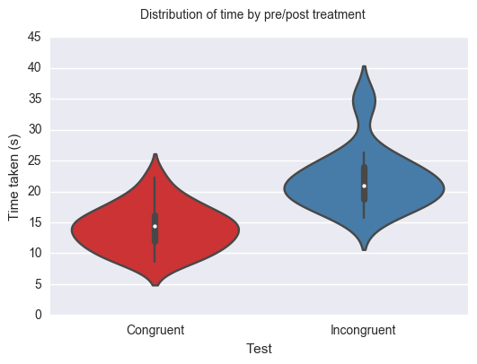

```python
## Melt the data for ease of visualisation
raw_data.melt = pd.melt(raw_data, var_name = 'Test', value_name = 'Time taken (s)')

## Violin plot by treatment
sns.violinplot(x="Test", y="Time taken (s)", data=raw_data.melt, palette="Set1");
plt.suptitle('Distribution of time by pre/post treatment')
```

As expected, a shift in the time taken to complete the test can be observed. Whilst it may appear clear, this is not enough for us *Numerati*, we must now evaluate the difference for statistical significance!

### Conducting the test

First up, what are our parameters?

*Degrees of Freedom:* 23 *Alpha $\alpha$:* 0.05 *Test Type:* Two tailed tTest

By looking at the tTest table from the lectures, it appears that our critical T is +- 2.069.

```python
## Conduct t-Test
raw_data.tTest = sp.stats.ttest_rel(raw_data.iloc[:,0], raw_data.iloc[:,1])
t = raw_data.tTest[0]
p = raw_data.tTest[1]

print "The t-statistic is %.3f and the p-value is %.3f." % raw_data.tTest
```

```
The t-statistic is -8.021 and the p-value is 0.000.
```

Given our p-value is so low and of course, our t-statistic far below our critical t, the difference in means is statistically significant at an $\alpha$ of 0.05.

### Areas of application

It would appear that by the brain can better process words than colours. This can be used effectively in marketing by attaching meaningful or emotive terms to a product, which is not usually associated with that type of item. This can help with brand differentiation. For example:

> *"Words like “tough,” “easy,” “simple” and “revolutionary” can be used to focus the viewer's or reader's attention."*

```
                                                                                        Walter Johnson
```

Evil marketers...

### References

Walter Johnson. 2017. Stroop Effect in Marketing. [ONLINE] Available at: http://smallbusiness.chron.com/stroop-effect-marketing-31368.html. [Accessed 3 December 2017].

https://docs.scipy.org/doc/scipy-0.14.0/reference/generated/scipy.stats.ttest_rel.html#scipy.stats.ttest_rel